# Final Project

Guglielmo Tornesi, Michael Gleyzer

5/4/2022

## Final Project Data Wrangling Report

### Scraping and dataset creation

We selected the following url: https://www.basketball-reference.com/leagues/NBA_2022_per_game.html for our data source, which we scraped with the “rvest” library. The dataset contains per game statistics about each player. After reading the html page and its table, we rendered the data as a tibble.

```
## # A tibble: 842 x 30
##    Rk    Player Pos   Age   Tm    G     GS    MP    FG    FGA   `FG%` `3P`
##    <chr> <chr>  <chr> <chr> <chr> <chr> <chr> <chr> <chr> <chr> <chr> <chr>
##  1 1     Preci~ C     22    TOR   73    28    23.6  3.6   8.3   .439  0.8
##  2 2     Steve~ C     28    MEM   76    75    26.3  2.8   5.1   .547  0.0
##  3 3     Bam A~ C     24    MIA   56    56    32.6  7.3   13.0  .557  0.0
##  4 4     Santi~ PF    21    MEM   32    0     11.3  1.7   4.1   .402  0.2
##  5 5     LaMar~ C     36    BRK   47    12    22.3  5.4   9.7   .550  0.3
##  6 6     Nicke~ SG    23    TOT   65    21    22.6  3.9   10.5  .372  1.6
##  7 6     Nicke~ SG    23    NOP   50    19    26.3  4.7   12.6  .375  1.9
##  8 6     Nicke~ SG    23    UTA   15    2     9.9   1.1   3.2   .333  0.7
##  9 7     Grays~ SG    26    MIL   66    61    27.3  3.9   8.6   .448  2.4
## 10 8     Jarre~ C     23    CLE   56    56    32.3  6.6   9.7   .677  0.0
## # ... with 832 more rows, and 18 more variables: `3PA` <chr>, `3P%` <chr>,
## #   `2P` <chr>, `2PA` <chr>, `2P%` <chr>, `eFG%` <chr>, FT <chr>, FTA <chr>,
## #   `FT%` <chr>, ORB <chr>, DRB <chr>, TRB <chr>, AST <chr>, STL <chr>,
## #   BLK <chr>, TOV <chr>, PF <chr>, PTS <chr>
```

### Glossary

Rk – Rank  
Pos – Position  
Age – Player’s age on February 1 of the season  
Tm – Team  
G – Games  
GS – Games Started  
MP – Minutes Played Per Game  
FG – Field Goals Per Game  
FGA – Field Goal Attempts Per Game  
FG% – Field Goal Percentage  
3P – 3-Point Field Goals Per Game  
3PA – 3-Point Field Goal Attempts Per Game  
3P% – 3-Point Field Goal Percentage  
2P – 2-Point Field Goals Per Game  
2PA – 2-Point Field Goal Attempts Per Game  
2P% – 2-Point Field Goal Percentage  
eFG% – Effective Field Goal Percentage  
This statistic adjusts for the fact that a 3-point field goal is worth one more point than a 2-point field goal.  
FT – Free Throws Per Game  
FTA – Free Throw Attempts Per Game  
FT% – Free Throw Percentage  
ORB – Offensive Rebounds Per Game  
DRB – Defensive Rebounds Per Game  
TRB – Total Rebounds Per Game  
AST – Assists Per Game  
STL – Steals Per Game  
BLK – Blocks Per Game  
TOV – Turnovers Per Game  
PF – Personal Fouls Per Game  
PTS – Points Per Game

### Data cleaning

The cleaning process was mainly based on 3 steps:

- Using the glimpse functions to check if any change in the variables names was needed
- Converting char data to integer data
- Eliminating label lines from the tibble

```
## Rows: 842
## Columns: 30
## $ Rk     <chr> "1", "2", "3", "4", "5", "6", "6", "6", "7", "8", "9", "10",...
## $ Player <chr> "Precious Achiuwa", "Steven Adams", "Bam Adebayo", "Santi Al...
## $ Pos    <chr> "C", "C", "C", "PF", "C", "SG", "SG", "SG", "SG", "C", "PG",...
## $ Age    <chr> "22", "28", "24", "21", "36", "23", "23", "23", "26", "23", ...
## $ Tm     <chr> "TOR", "MEM", "MIA", "MEM", "BRK", "TOT", "NOP", "UTA", "MIL...
## $ G      <chr> "73", "76", "56", "32", "47", "65", "50", "15", "66", "56", ...
## $ GS     <chr> "28", "75", "56", "0", "12", "21", "19", "2", "61", "56", "1...
## $ MP     <chr> "23.6", "26.3", "32.6", "11.3", "22.3", "22.6", "26.3", "9.9...
## $ FG     <chr> "3.6", "2.8", "7.3", "1.7", "5.4", "3.9", "4.7", "1.1", "3.9...
## $ FGA    <chr> "8.3", "5.1", "13.0", "4.1", "9.7", "10.5", "12.6", "3.2", "...
## $ `FG%`  <chr> ".439", ".547", ".557", ".402", ".550", ".372", ".375", ".33...
## $ `3P`   <chr> "0.8", "0.0", "0.0", "0.2", "0.3", "1.6", "1.9", "0.7", "2.4...
## $ `3PA`  <chr> "2.1", "0.0", "0.1", "1.5", "1.0", "5.2", "6.1", "2.2", "5.9...
```

[output cut: 17 more lines]

### Final dataset

```
## # A tibble: 812 x 30
##    Rk    Player Pos     Age Tm        G    GS    MP    FG   FGA `FG%`  `3P`
##    <chr> <chr>  <chr> <dbl> <chr> <dbl> <dbl> <dbl> <dbl> <dbl> <dbl> <dbl>
##  1 1     Preci~ C        22 TOR      73    28  23.6   3.6   8.3 0.439   0.8
##  2 2     Steve~ C        28 MEM      76    75  26.3   2.8   5.1 0.547   0
##  3 3     Bam A~ C        24 MIA      56    56  32.6   7.3  13   0.557   0
##  4 4     Santi~ PF       21 MEM      32     0  11.3   1.7   4.1 0.402   0.2
##  5 5     LaMar~ C        36 BRK      47    12  22.3   5.4   9.7 0.55    0.3
##  6 6     Nicke~ SG       23 TOT      65    21  22.6   3.9  10.5 0.372   1.6
##  7 6     Nicke~ SG       23 NOP      50    19  26.3   4.7  12.6 0.375   1.9
##  8 6     Nicke~ SG       23 UTA      15     2   9.9   1.1   3.2 0.333   0.7
##  9 7     Grays~ SG       26 MIL      66    61  27.3   3.9   8.6 0.448   2.4
## 10 8     Jarre~ C        23 CLE      56    56  32.3   6.6   9.7 0.677   0
## # ... with 802 more rows, and 18 more variables: `3PA` <dbl>, `3P%` <dbl>,
## #   `2P` <dbl>, `2PA` <dbl>, `2P%` <dbl>, `eFG%` <dbl>, FT <dbl>, FTA <dbl>,
## #   `FT%` <dbl>, ORB <dbl>, DRB <dbl>, TRB <dbl>, AST <dbl>, STL <dbl>,
## #   BLK <dbl>, TOV <dbl>, PF <dbl>, PTS <dbl>
```

### Dataset download

After the cleaning process, we downloaded the file as a csv.

### Data analysis

First, we analyzed the top 5 scorers in the dataset. Then we created a barplot with the names of the top scorers and their scores. Moreover, we scraped the image of the player with the highest score and inserted it on his player bar.

[figure not shown]

### Relationship between the amount of points scored and time played

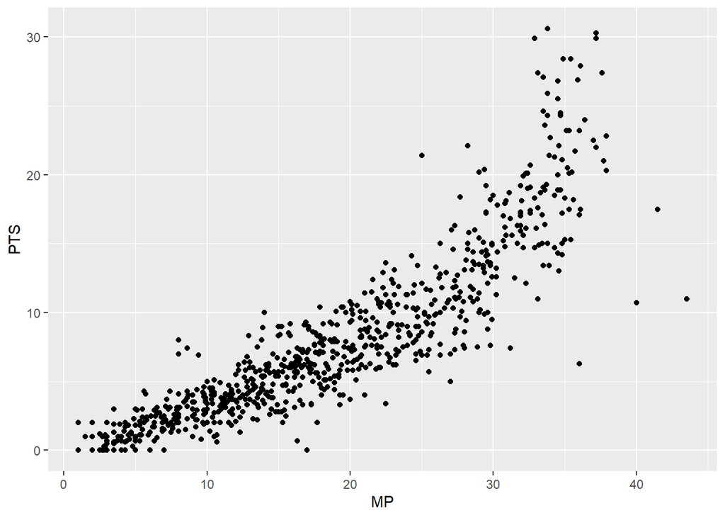

We can observe a clear positive correlation between the number of minutes played per game and the number of points scored. Thus, we can conclude that the longer a player stays in the game, the larger the number of points they will score.

### Top teams by points

```
##    Tm   PTS
## 1 POR 264.1
## 2 IND 255.6
## 3 OKC 234.7
## 4 BRK 224.6
## 5 SAC 217.7
## 6 WAS 209.5
```

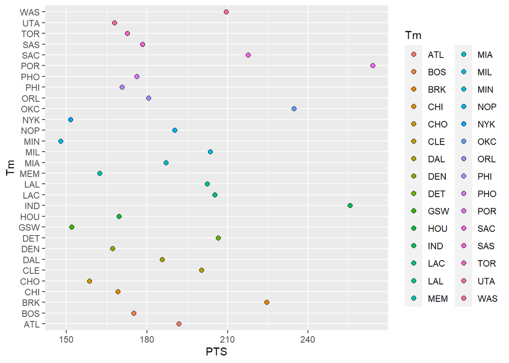

According to the chart, POR(Portland Trail Blazers) leads all the other teams in total points scored, because it has more top scorers than any other team in the dataset. POR is followed by IND(The Indiana Pacers) and OKC(the Oklahoma city thunder) as the next two teams with the highest total points scored.

### Top scorer by position

Next, we analyzed which player positions(point guard,shooting guard..etc.) resulted in the most points scored.

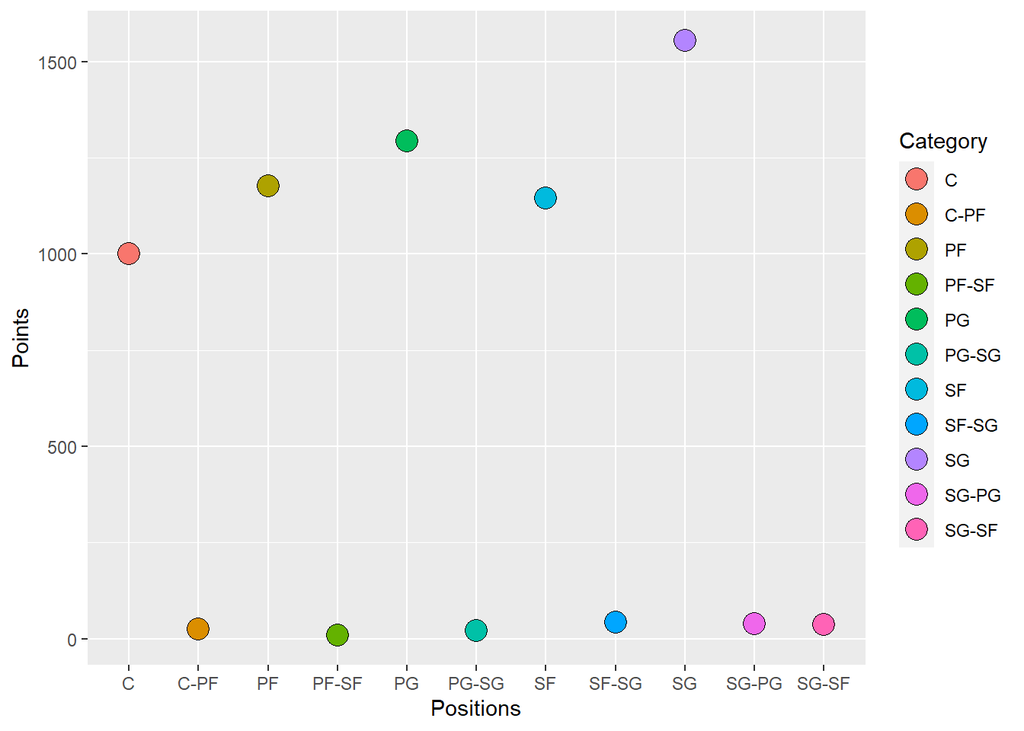

After plotting the results, we can state that the top 3 categories are:

- Shooting guards
- Point Guards
- Power Forward

It makes sense that shooting guards and point guards are the top two scoring positions , because they are most involved in the offensive aspect of the game.

[figure not shown]

### Number of FT, 3P, 2P by position

After having analyzed the number of points scored by each position, we were interested in discovering what types of shots are taken by each type of player.

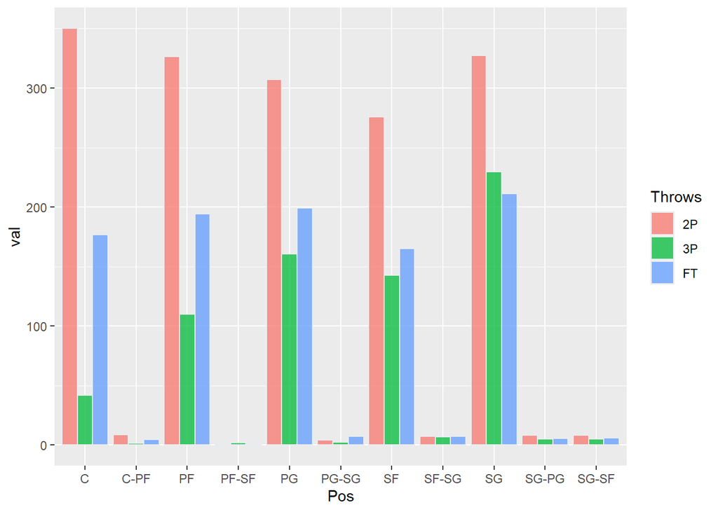

### Goal percentages by team

In this part of the analysis, we had to account for missing data in the form of NAs. The reason why we waited till this moment, is because these are the only columns with NAs. We realized that previous analysis worked fine with missing data, and we didn’t want to lose observations for previous tasks.

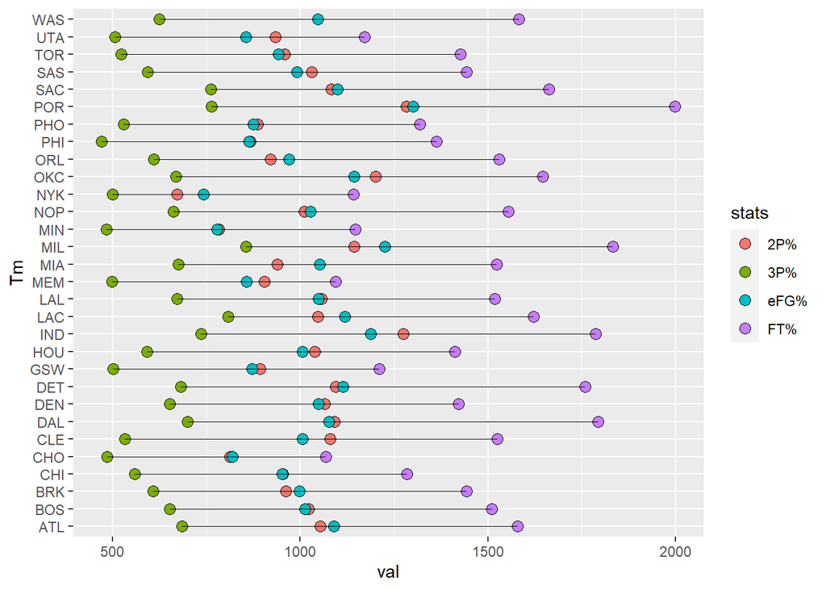

From the graph we can see that in all the teams the highest percentage shots are free throws.The next highest percentage statistics are field goal percentage and 2 point percentage. Finally, given that the 3 pointer is the hardest shot in basketball, the 3 point percentage is the lowest for all the teams.

### Regression

```
##
## Call:
## lm(formula = PTS ~ ORB + DRB + AST, data = NBA_table)
##
## Residuals:
##      Min       1Q   Median       3Q      Max
## -15.1811  -1.8833  -0.3817   1.6670  12.6543
##
## Coefficients:
##             Estimate Std. Error t value Pr(>|t|)
## (Intercept)  0.83541    0.20590   4.057 5.44e-05 ***
## ORB         -0.87666    0.22768  -3.850 0.000127 ***
## DRB          2.03947    0.11069  18.426  < 2e-16 ***
## AST          1.41052    0.08078  17.461  < 2e-16 ***
## ---
## Signif. codes:  0 '***' 0.001 '**' 0.01 '*' 0.05 '.' 0.1 ' ' 1
##
## Residual standard error: 3.282 on 808 degrees of freedom
## Multiple R-squared:  0.7151, Adjusted R-squared:  0.7141
## F-statistic: 676.1 on 3 and 808 DF,  p-value: < 2.2e-16
```

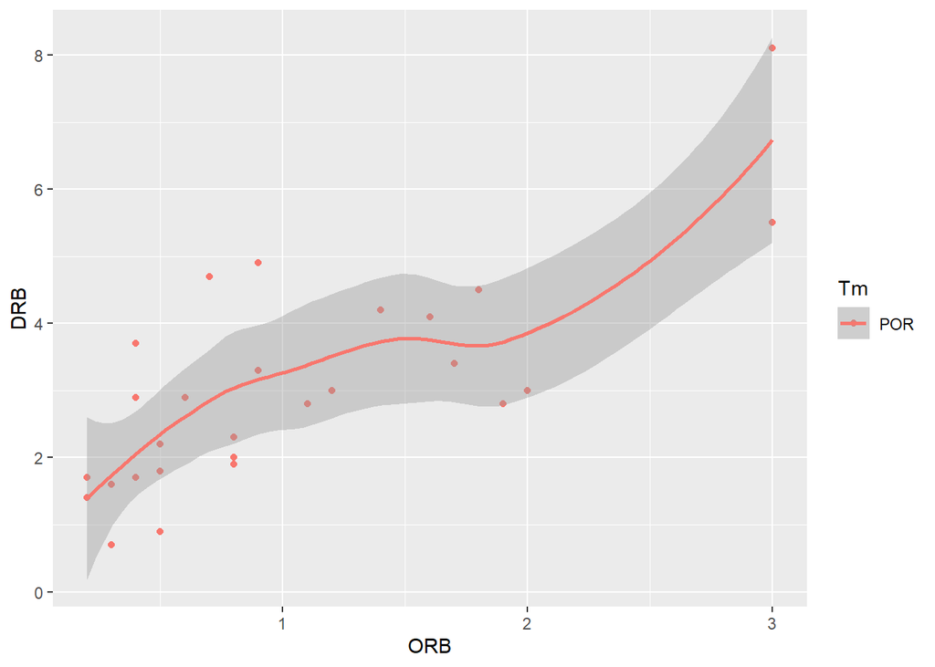

Consequently we did a subgroup regression analysis with grouping by team.

Then we collected the coefficients for offensive rebounds. (we picked randomly, the same analysis could have been done also for the other kind of throws) and then we plotted the estimated coefficients across teams. The offensive rebounds coefficient is negative for most teams, which suggests that generally speaking offensive rebounds are negatively correlated with points per game. This makes sense as offensive rebounds occur after missed two point or three point shots.

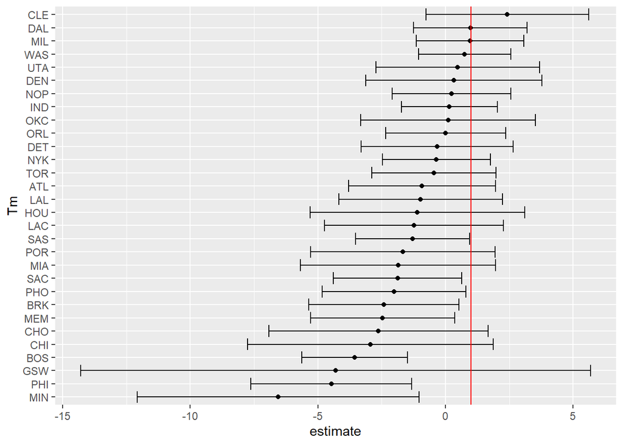

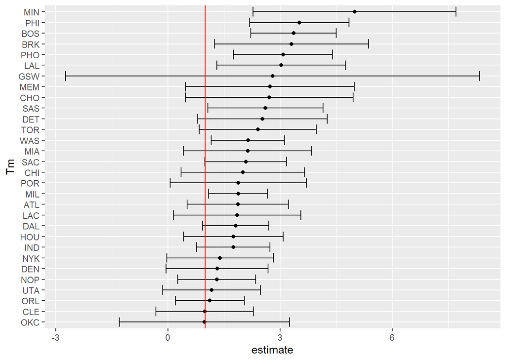

Finally, we collected regression coefficients for the assist variable. Clearly most teams show a positive correlation between assists and points per game. This is a reasonable result as ball movement is very important in making the attacking team harder to defend, which allows them to score more points.

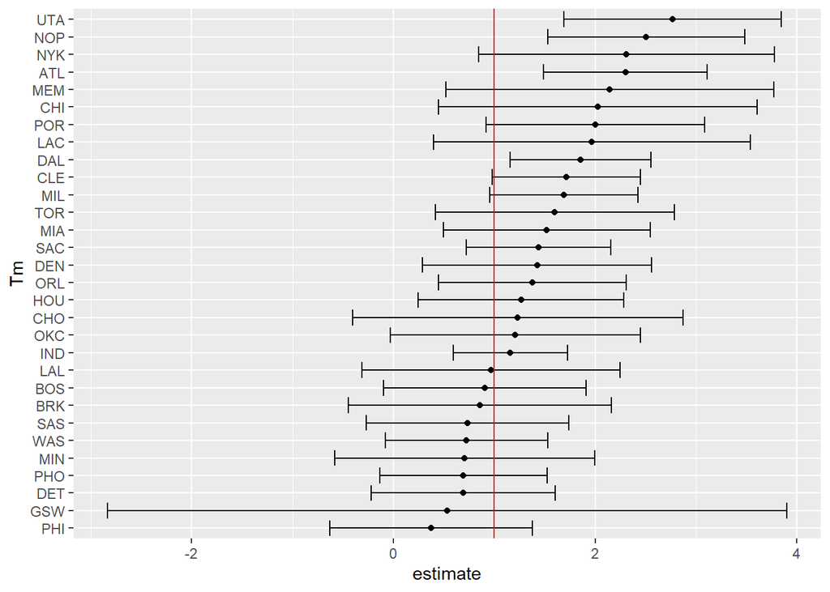